# Problem Set 10

#### Data Analysis: Education and Ethnicity in LA

Researchers in demography were interested in capturing the relationship between the ethnic make up of neighborhoods and the level of education. To gather data they took a random sample of 100 neighborhoods and recorded the proportion of residents in each that identified as hispanic and the proportion of residents that had graduated from college. The data can be loaded with the following command:

```r
LA <- read.csv("http://andrewpbray.github.io/data/LAed.csv")
```

1. Plot the relationship between ethnicity and education, keeping in mind the norm of putting the independent variable on the x-axis. Please describe the structure in the plot as well as any unusual observations.

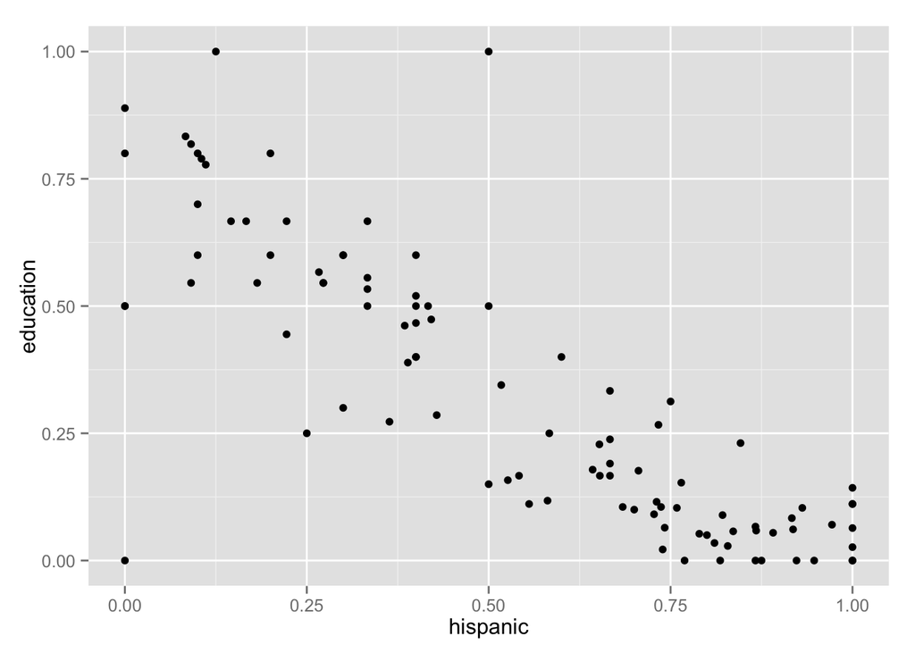

```r
library(ggplot2)
qplot(x = hispanic, y = education, data = LA, geom = "point")
```

*There is a fairly linear, negative, moderately strong relationship between proportion of hispanic residents in a neighborhood and the college graduation rate. There are several notable outliers, including neighborhoods with graduation rates of 1 and another with a graduation rates of zero and a hispanic propotion also of zero.*

2. Fit a linear model to this scatterplot. Have you found a predictor that is statistically significant? In your regression output, what do you look for as evidence and how do you interpret it?

```r
m1 <- lm(education ~ hispanic, data = LA)
summary(m1)
```

```
##
## Call:
## lm(formula = education ~ hispanic, data = LA)
##
## Residuals:
##      Min       1Q   Median       3Q      Max
## -0.72903 -0.07675  0.00229  0.08530  0.64730
##
## Coefficients:
##             Estimate Std. Error t value Pr(>|t|)
## (Intercept)  0.72903    0.03078   23.68   <2e-16 ***
## hispanic    -0.75265    0.05015  -15.01   <2e-16 ***
## ---
## Signif. codes:  0 '***' 0.001 '**' 0.01 '*' 0.05 '.' 0.1 ' ' 1
##
## Residual standard error: 0.1516 on 98 degrees of freedom
## Multiple R-squared:  0.6969, Adjusted R-squared:  0.6938
## F-statistic: 225.3 on 1 and 98 DF,  p-value: < 2.2e-16
```

*The p-value associated with the slope on hispanic is very small, so we have evidence that it is statistically significantly different from zero. There does appear to be a relationship between these two variables.*

3. Was your inference conclusion based on a valid model? Please use plots to assess the conditions for regression.

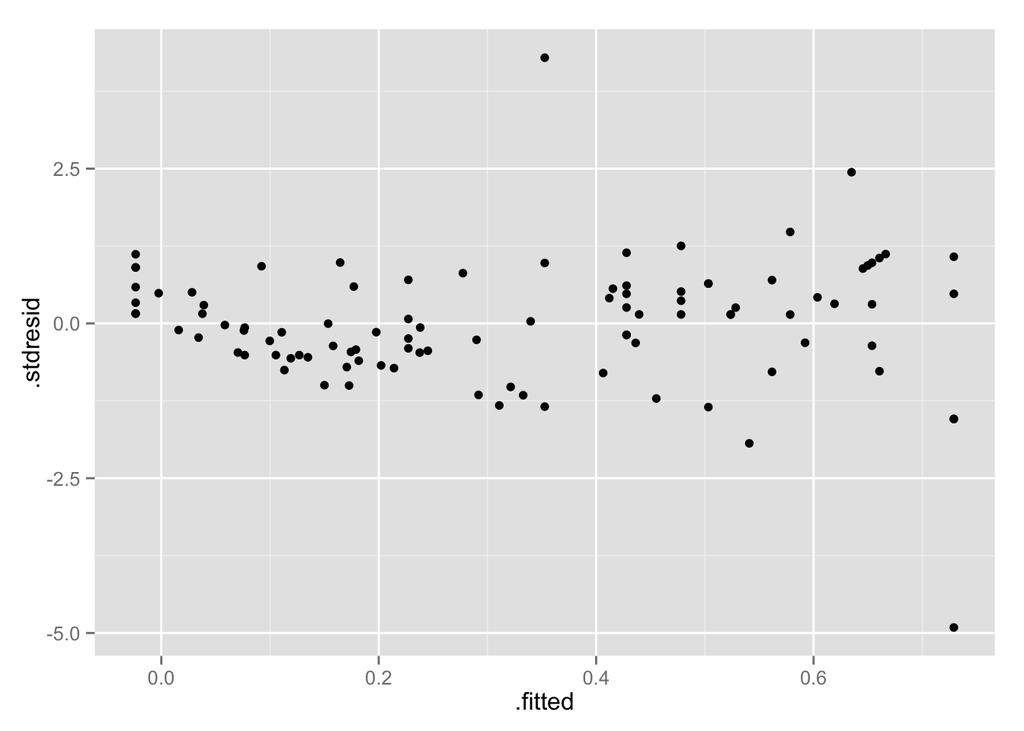

```r
qplot(x = .fitted, y = .stdresid, data = m1)
```

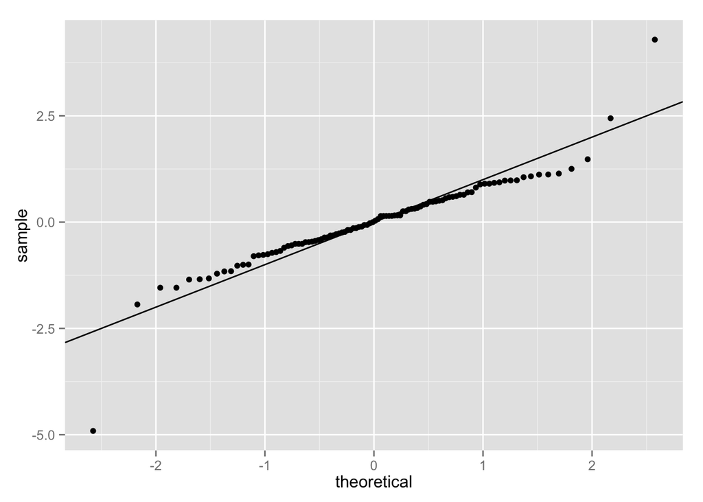

```r
qplot(sample = .stdresid, data = m1) + geom_abline()
```

#### Reading

To be read next week…

#### Practice Problems

Chapter 6, number 4 (not d), 5, and 6.